# Lab 6 Loops and Functions

Anna Abelman

11/5/2019

```r
library(tidyverse)
```

# Why functions?

- They make it easy to do a task over and over without copy-and-paste the code.
- You can take a complicated piece of code and give it a useful descriptive name

## Making a basic function

Make a function to take a number and add 1.

```r
add_one <- function(x){
  y <- x + 1
}

z <- add_one(x = 4)
zz <- add_one(3:7)
zz
```

```
## [1] 4 5 6 7 8
```

```r
add_some <- function(x, a = 1){
  y <- x + a
  print("yay!")
  return(y)
}

z <- add_some(x = 4, a = 3)
```

```
## [1] "yay!"
```

```r
z
```

```
## [1] 7
```

## Make a useful function!

A good place is to use verb names for your functions.

Let’s make a function to calculate the mean of a vector of values. First, let’s create a test vector of values we can use for testing. We’ll use ‘rnorm()’ to generate a pseudo-random set of numbers as a working sample, with a knwon mean and standard deviation.

```r
set.seed(12345) ### can be any number, but as long as we all use the same, we should get the same smaple
test_vec <- rnorm(n = 100, mean = 1, sd = 1)
head(test_vec)
```

```
## [1]  1.5855288  1.7094660  0.8906967  0.5465028  1.6058875 -0.8179560
```

```r
mean(test_vec)
```

```
## [1] 1.245197
```

```r
sd(test_vec)
```

```
## [1] 1.114731
```

```r
calc_mean <- function(x){
  n <- length(x)
  my_mean <- sum(x)/n
  return(my_mean)
}

calc_mean(test_vec)
```

```
## [1] 1.245197
```

```r
calc_mean
```

```
## function(x){
##   n <- length(x)
##   my_mean <- sum(x)/n
##   return(my_mean)
## }
```

## Anatomy of a function:

- function() is a function that defines functions.
- inside the arguments for ‘function(…)’ are the information we need to five the function for it to do its job.
- after the arguments, inside the {}, we put the code that defines what the function does.
- at the end, the ‘return()’ gives back to the user the desired output of the function.

##Environments

Most of the time we’re working in the Global Environment.

When you execute a function, R starts a new independent environment, like a pocket universe, separate from the global environment. The arguments (in this case, x) allow a window through which we can pass information to that new environment; the return() is a window to pass information back

```r
x <- 100
y <- 200
z <- add_one(x = 8)
add_one
```

```
## function(x){
##   y <- x + 1
## }
## <bytecode: 0x000000001840f180>
```

```r
x
```

```
## [1] 100
```

```r
y
```

```
## [1] 200
```

Note: the changes in variables inside the function are NOT communicated back to the global environment. That’s a good thing!

A well-written function should communicate with the golabl environment only through arguments and return values.

Once the function finishes, that new environment/universe return its value then disappears forever.

## Improving our basic function

A well-written function should anticipate when the user might have imperfect data. Error checks or additional arguments can be helpful. When might out calc_mean() function break down?

```r
calc_mean(1:10) # ok
```

```
## [1] 5.5
```

```r
calc_mean(x = 1:10) #cool
```

```
## [1] 5.5
```

```r
#calc_mean(y = 1:10) #fails
#calc_mean() #fails
#calc_mean(x = c(1,2,3,4,NA)) #fails
```

## Let’s create a test vector with some NAs

Also, let’s learn about indexing to access specific elements in a vector. Use “index” numbers to tell which elements of the vector to change.

```r
test_vec_w_NA <- test_vec ###just a copy

test_vec_w_NA[5] <- NA
test_vec_w_NA[10:15] <- NA
test_vec_w_NA[c(20,22,24)] <- NA

calc_mean(test_vec_w_NA)
```

```
## [1] NA
```

What do we nedd to do to make our function work with NAs?

- design in an na.rm argument to allow the user to decide whether to exclude NAs
- design in a way to exclude NAs if the user ask

### Another quick thing with vectors:

How to exclude NAs?

```r
z <- c(1:5, NA)
z
```

```
## [1]  1  2  3  4  5 NA
```

```r
is.na(z)
```

```
## [1] FALSE FALSE FALSE FALSE FALSE  TRUE
```

```r
!is.na(z)
```

```
## [1]  TRUE  TRUE  TRUE  TRUE  TRUE FALSE
```

```r
zz <- z[!is.na(z)]
zz
```

```
## [1] 1 2 3 4 5
```

```r
calc_mean2 <- function(x_vec, na.rm = TRUE){
  if(na.rm == TRUE){
    x_vec <- x_vec[!is.na(x_vec)]
  }
  n <- length(x_vec)
  mymean <- sum(x_vec)/n
  return(mymean)
}

calc_mean2(test_vec_w_NA)
```

```
## [1] 1.253227
```

```r
# this is an example of the function we created using the iris data in R
data(iris)
iris_mean <- iris %>%
  janitor::clean_names() %>%
  group_by(species) %>%
  summarize(mean_sepal_w = calc_mean2(sepal_width))
```

# Why loops?

Sometimes you want to do a thing many times, i.e. iterate. Loops are one way to do this, especially if you have a vector of values and you want to a calcuate something based on each value.

```r
times <- 10

for(i in 1:times){
  print(i + 1)
}
```

```
## [1] 2
## [1] 3
## [1] 4
## [1] 5
## [1] 6
## [1] 7
## [1] 8
## [1] 9
## [1] 10
## [1] 11
```

```r
x <- 1
for(j in 1:times){
  x <- x + j
  print(x)
}
```

```
## [1] 2
## [1] 4
## [1] 7
## [1] 11
## [1] 16
## [1] 22
## [1] 29
## [1] 37
## [1] 46
## [1] 56
```

```r
for(k in 1:times){
  print("hello world!")
}
```

```
## [1] "hello world!"
## [1] "hello world!"
## [1] "hello world!"
## [1] "hello world!"
## [1] "hello world!"
## [1] "hello world!"
## [1] "hello world!"
## [1] "hello world!"
## [1] "hello world!"
## [1] "hello world!"
```

A standard die roll has equal chances to land oneach of its six sides. Use sample() to simulate this.

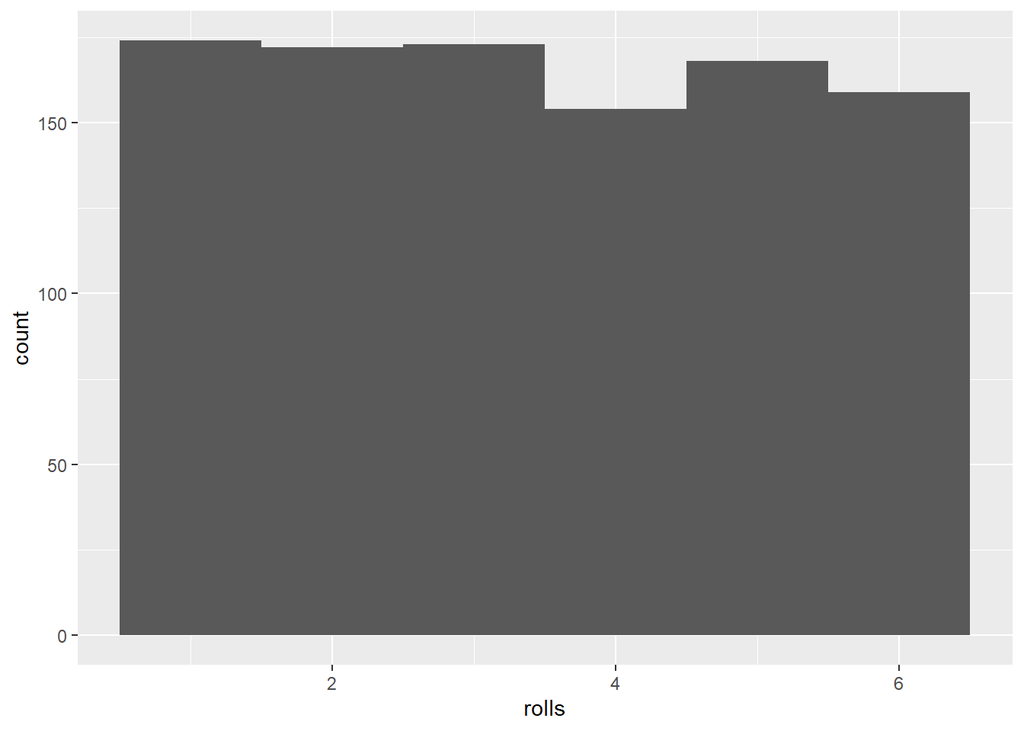

```r
die_rolls <- data.frame(rolls = sample(x = 1:6, size = 1000, replace = TRUE))



ggplot(data.frame(die_rolls), aes(x = rolls))+
  geom_histogram(bins = 6)
```

OK, now let’s use a loop to make a bunch of simulations, each of 20 rolls, and calculate the mean of each.

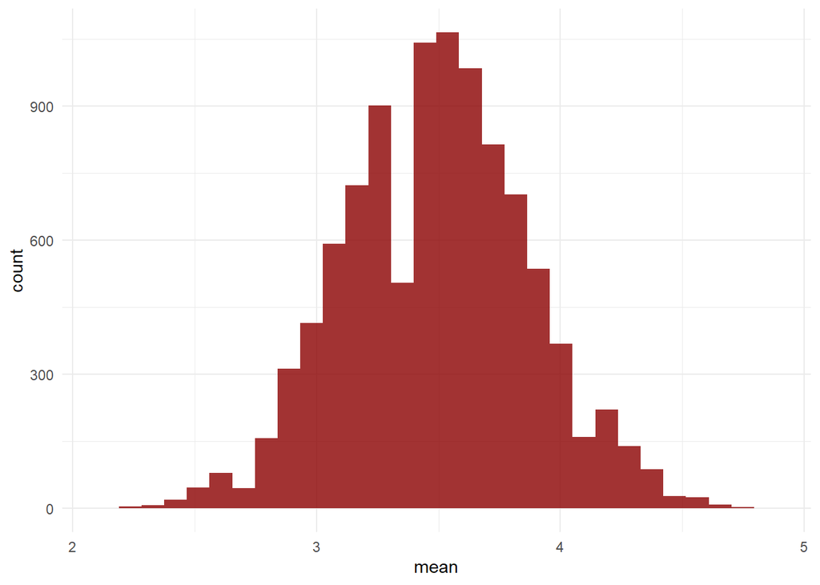

```r
set.seed(42)
sims <- 10000

mean_results <- vector('numeric', length = sims)

for(i in 1:sims){
  rolls_vec <- sample(1:6, size = 20, replace = TRUE)
  rolls_mean <- calc_mean2(rolls_vec)
  mean_results[i] <- rolls_mean
}
results_df <- data.frame(sim = 1:sims,
                         mean = mean_results)

ggplot(results_df, aes(x = mean))+
  geom_histogram(alpha = .8,
                 fill = "darkred")+
  theme_minimal()
```

If die rolls are uniformly distributed, why do we see a normal distribution here? Central Limit Theorem!